*Last Updated 2015-02-02*

# Dirt

This is the track profile for all 7 furlong dirt races at Gulfstream Park, there are **232** races in the dataset, contested by **1869** runners. The oldest race in the dataset was run on **2012-12-01** while the most recent was run on **2015-01-31**.

### Summary

A few quick and dirty summary plots highlighting the different race types and field sizes. **CLM** races are the most common over the 7 furlong course, with **84** races. The average field size for 7 furlong races is **8.06**.

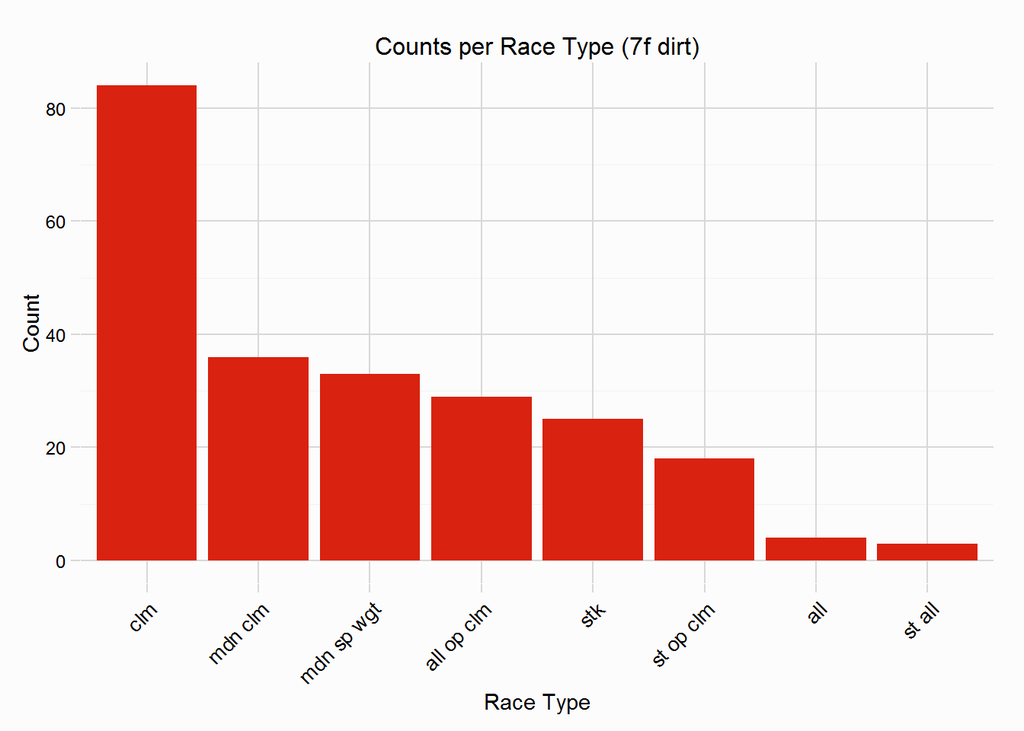

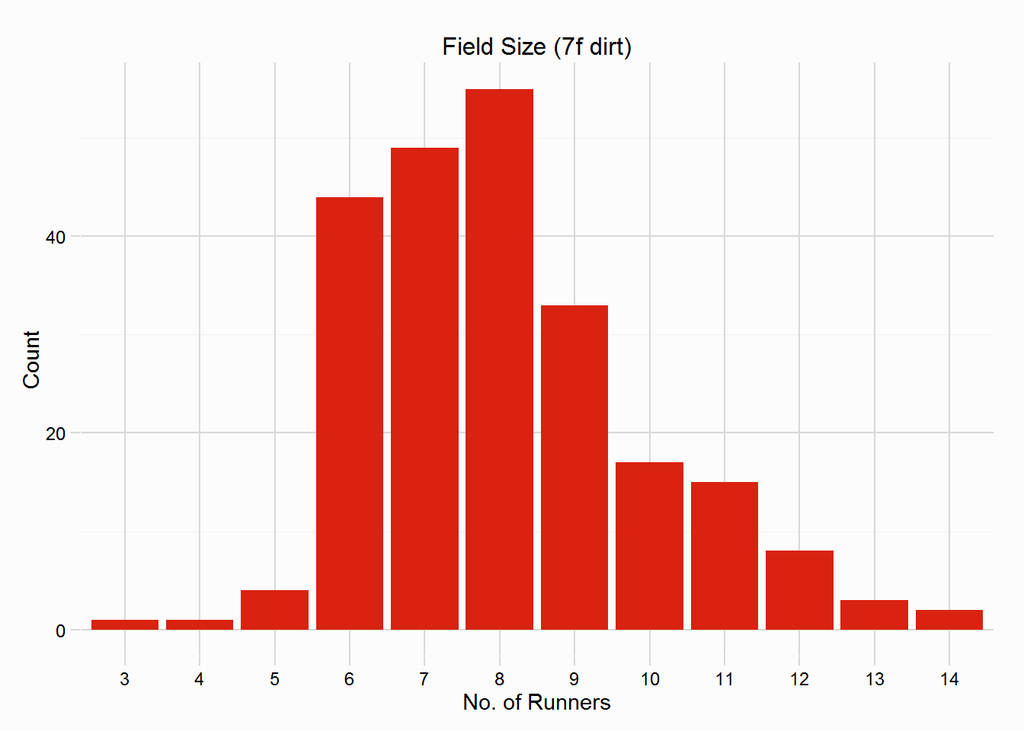

### Draw

The 7 furlong course is run round one turn, which starts roughly 3 furlongs from the starting gates, and continues for roughly 2 furlongs, meaning the home straight is ~2f. Counting winners is the typical way to assess any draw bias, but winners ignore a large number of runners, and if there was any such bias, it should be seen across all runners, so percentage of runners beaten is to be used (gates must have a minimum of 5 runs):

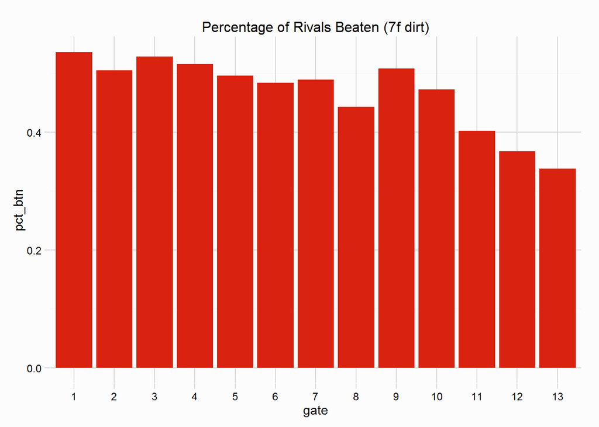

A fair draw would expect to see each draw beat 50% of their rivals.

The draw will likely have an impact on the distance horses travel, especially as the first and only turn is such a short distance from the start. Horses drawn wide (high) will likely be forced wide. Unsurprisingly, horses drawn in gate **1** travel the least distance, with an average trip of **4664.77** feet, while horses draw in gate **12** travel an average distance of **4688.15**, a difference of **23.38** feet (gates must have a minimum of 5 runs used). The plot below shows boxplots of distance raced by horses in each starting gate.

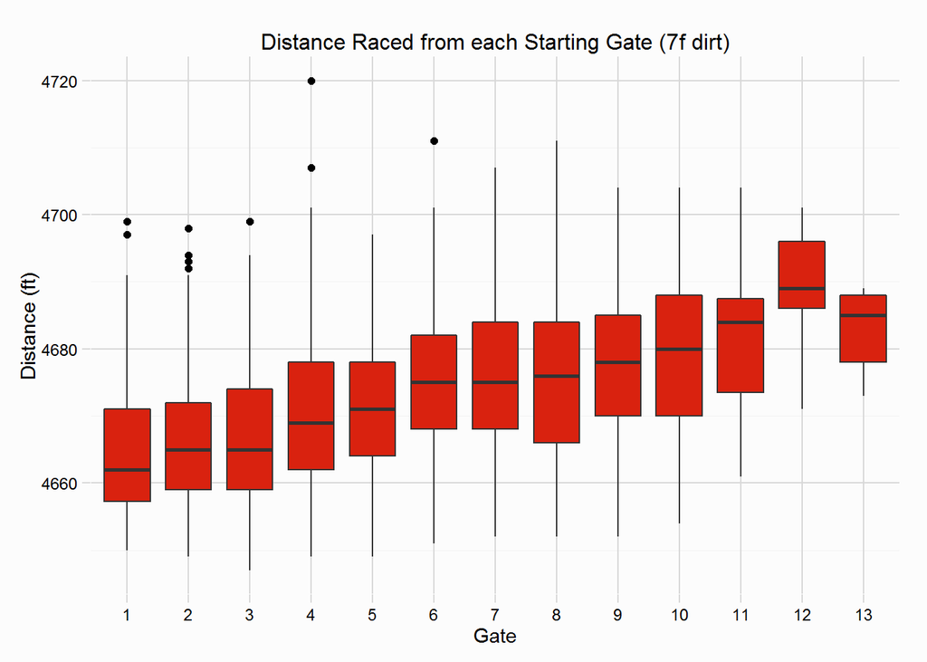

### Race Shape

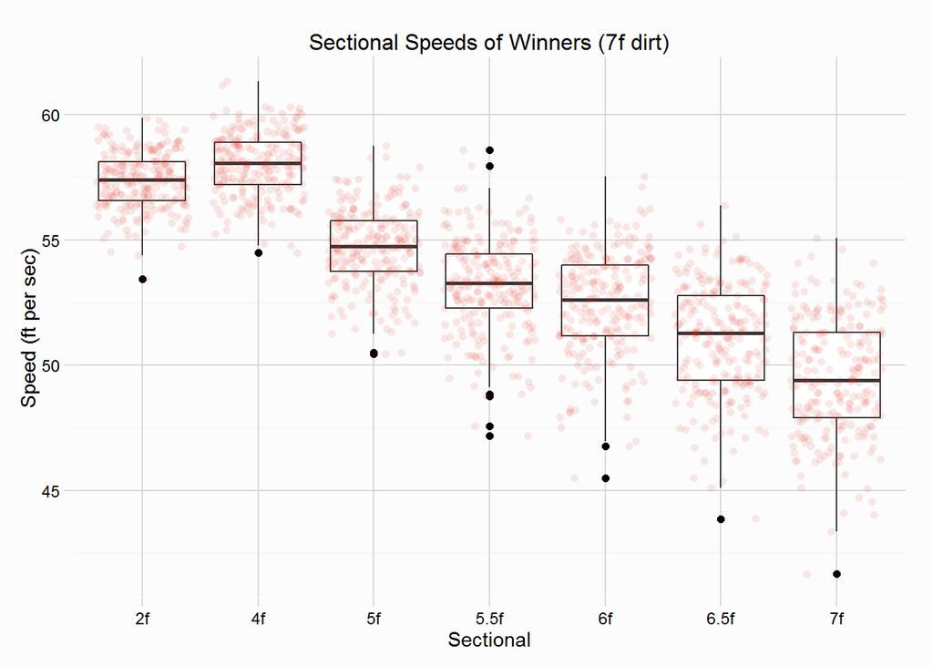

The fastest opening quarter by a horse who went on to win was by **ANILLO** on 04/07/13 in race 6, recording a speed of **59.85** feet per second. There were horses who ran faster, PUDDIFOOT ran the opening quarter in a speed of 60.25 ft per second.

### Pace

Finishing Speeds also reflect the slowing to the finish shown in the Race Shape plot above, this will in part be due to the dirt surface (horses slow at the finish over longer trips also). The par finishing speeds for 7f winners are:

```
##   5f FinSpd   3f FinSpd   2f FinSpd 1.5f FinSpd   1f FinSpd 0.5f FinSpd
##      0.9848      0.9472      0.9316      0.9231      0.9102      0.8962
```

The plots below show the distribution of 5f Finishing Speeds for winners compared to “The Rest”, and the opening 2f sectionals for winners compared to “The Rest”. The distributions are similar, not surprising to see “The Rest” with a fatter distribution in both plots, perhaps most interesting is that the winners not only record higher Finishing Speeds than “The Rest”, but they are also faster over the opening 2f. Winners, on average, run the opening 2f in **23.17**, compared to “The Rest”, who run the opening 2f in **23.41**, a difference of **0.24** seconds. For reference, the horses leading their race after 2f run the opening 2f in an average time of **22.94**.

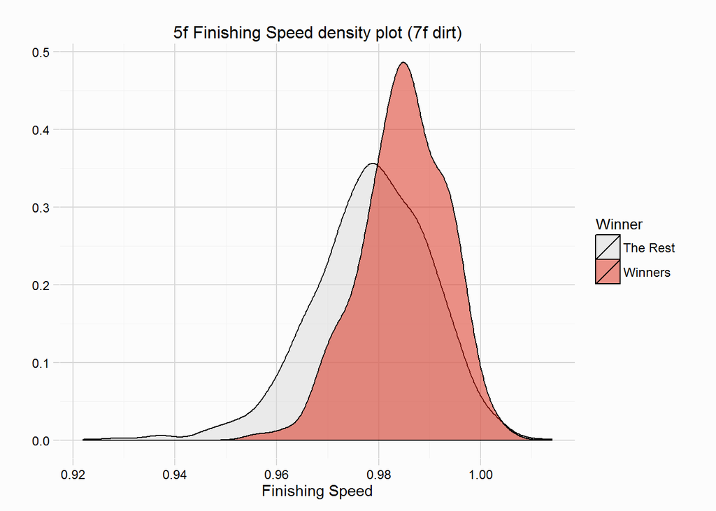

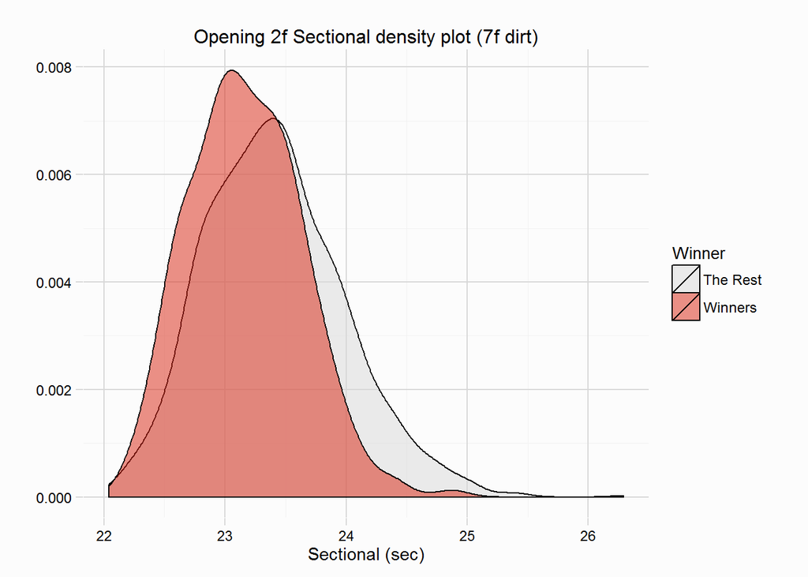

Plotting the opening 2f sectional against the closing 5f Finishing Speeds the difference becomes a little more clear. The cloud of points is crowded but winners are, for the majority, in the upper left part of the cloud.

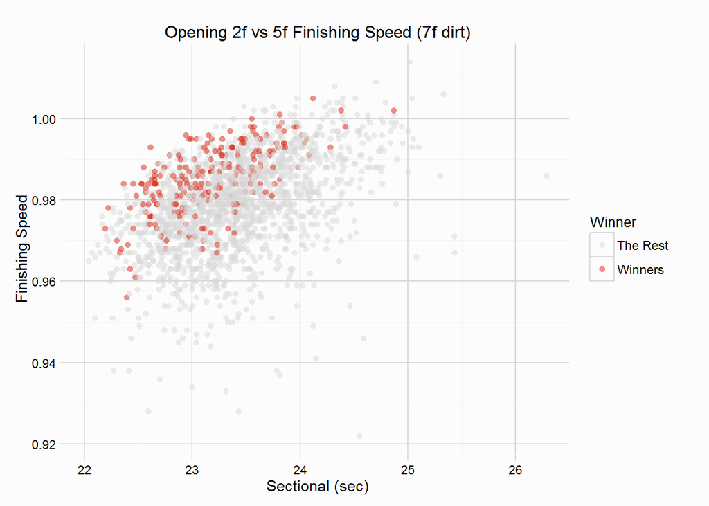